# Project 7: Difference-in-Differences and Synthetic Control

# Synthetic Control

Estimate Synthetic Control

Although several states did not expand Medicaid on January 1, 2014, many did later on. In some cases, a Democratic governor was elected and pushed for a state budget that included the Medicaid expansion, whereas in others voters approved expansion via a ballot initiative. The 2018 election was a watershed moment where several Republican-leaning states elected Democratic governors and approved Medicaid expansion. In cases with a ballot initiative, the state legislature and governor still must implement the results via legislation. For instance, Idaho voters approved a Medicaid expansion in the 2018 election, but it was not implemented in the state budget until late 2019, with enrollment beginning in 2020.

Do the following:

- Choose a state that adopted the Medicaid expansion after January 1, 2014. Construct a non-augmented synthetic control and plot the results (both pre-treatment fit and post-treatment differences). Also report the average ATT and L2 imbalance.

```r
# non-augmented synthetic control

# Alaska expanded in Sept 2015

# Preprocessing for synthetic control analysis
data_for_synth <- medicaid_expansion %>%
  # Create treatment and time variables
  mutate(
    # For Alaska treatment
    treat = ifelse(State == "Alaska", 1, 0),
    # Create treatment time variable (Alaska expanded in 2015)
    post = ifelse(year >= 2015, 1, 0)
  ) %>%
  # Filter out states that expanded on Jan 1, 2014 from donor pool
  filter(is.na(Date_Adopted) | year(Date_Adopted) > 2014 | State == "Alaska")

# Run synthetic control model
syn_control <- augsynth(
  form = uninsured_rate ~ treat,
  unit = State,
  time = year,
  t_int = 2015,
  data = data_for_synth,
  progfunc = "None", # Plain synthetic control/non-augmented
  scm = TRUE
)
```

```
## One outcome and one treatment time found. Running single_augsynth.
```

```r
# View summary statistics - ATT and L2 imbalance
summary(syn_control)
```

```
##
## Call:
## single_augsynth(form = form, unit = !!enquo(unit), time = !!enquo(time),
##     t_int = t_int, data = data, progfunc = "None", scm = TRUE)
##
## Average ATT Estimate (p Value for Joint Null):  0.0147   ( 0.18 )
## L2 Imbalance: 0.028
## Percent improvement from uniform weights: 78.1%
##
## Avg Estimated Bias: NA
##
## Inference type: Conformal inference
##
##  Time Estimate 95% CI Lower Bound 95% CI Upper Bound p Value
##  2015    0.018             -0.019              0.055   0.489
##  2016    0.034             -0.003              0.071   0.381
##  2017    0.023             -0.014              0.060   0.501
##  2018    0.006             -0.031              0.044   0.741
##  2019    0.000             -0.037              0.037   1.000
##  2020    0.007             -0.031              0.044   0.744
```

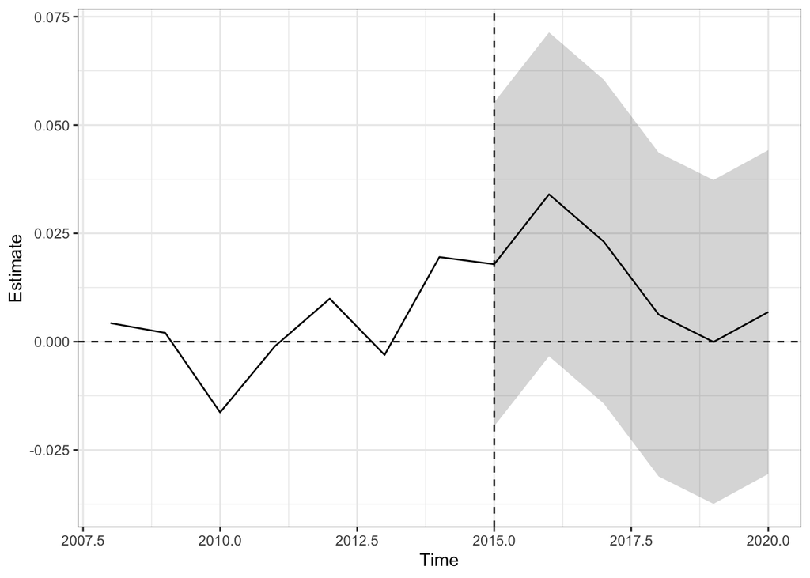

```r
# Plot pre-treatment fit and post-treatment differences
plot(syn_control)
```

Above, we see that the Average ATT Estimate is 0.0147 and the L2 Imbalance is: 0.028.

- Re-run the same analysis but this time use an augmentation (default choices are Ridge, Matrix Completion, and GSynth). Create the same plot and report the average ATT and L2 imbalance.

```r
# augmented synthetic control

# Using the same Alaska example but with Ridge augmentation

aug_syn_control <- augsynth(
  form = uninsured_rate ~ treat,
  unit = State,
  time = year,
  t_int = 2015,
  data = data_for_synth,
  progfunc = "Ridge", # Ridge augmentation
  scm = TRUE
)
```

```
## One outcome and one treatment time found. Running single_augsynth.
```

```r
# View summary statistics - ATT and L2 imbalance
summary(aug_syn_control)
```

```
##
## Call:
## single_augsynth(form = form, unit = !!enquo(unit), time = !!enquo(time),
##     t_int = t_int, data = data, progfunc = "Ridge", scm = TRUE)
##
## Average ATT Estimate (p Value for Joint Null):  0.0143   ( 0.19 )
## L2 Imbalance: 0.028
## Percent improvement from uniform weights: 78.3%
##
## Avg Estimated Bias: 0.000
##
## Inference type: Conformal inference
##
##  Time Estimate 95% CI Lower Bound 95% CI Upper Bound p Value
##  2015    0.017             -0.019              0.054   0.469
##  2016    0.034             -0.003              0.070   0.388
##  2017    0.023             -0.014              0.059   0.517
##  2018    0.006             -0.031              0.043   0.730
##  2019    0.000             -0.037              0.036   1.000
##  2020    0.006             -0.030              0.043   0.753
```

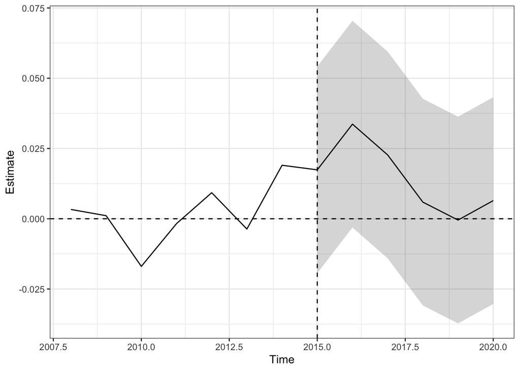

```r
# Plot pre-treatment fit and post-treatment differences
plot(aug_syn_control)
```

Above, we see that the Average ATT Estimate is 0.0143 and the L2 Imbalance is: 0.028.

- Plot barplots to visualize the weights of the donors.

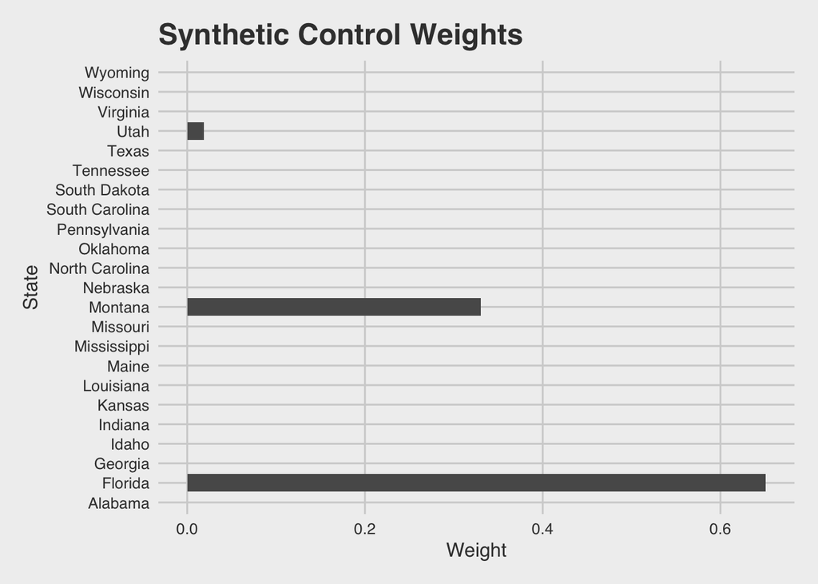

```r
# barplots of weights

# Non-augmented weights

# Extract donor weights for the non-augmented model
data.frame(syn_control$weights) %>% # coerce to data frame since it's in vector form
  # process
  # ---------
  # change index to a column
  tibble::rownames_to_column('State') %>% # move index from row to column (similar to index in row as in Python)
  # plot
  # ---------
  ggplot() +
  # stat = identity to take the literal value instead of a count for geom_bar()
  geom_bar(aes(x = State,
               y = syn_control.weights),
           stat = 'identity') +  # override count() which is default of geom_bar(), could use geom_col() instead
  coord_flip() +   # flip to make it more readable
  # themes
  theme_fivethirtyeight() +
  theme(axis.title = element_text()) +
  # labels
  ggtitle('Synthetic Control Weights') +
  xlab('State') +
  ylab('Weight')
```

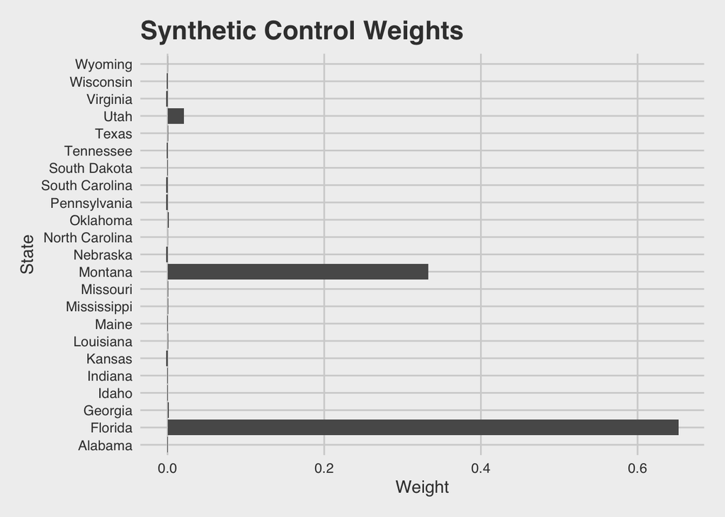

```r
# Augmented weights
data.frame(aug_syn_control$weights) %>%
  tibble::rownames_to_column('State') %>%
  ggplot() +
  geom_bar(aes(x = State, y = aug_syn_control.weights),
           stat = 'identity') +
  coord_flip() + # coord flip
  theme_fivethirtyeight() +
  theme(axis.title = element_text()) +
  ggtitle('Synthetic Control Weights') +
  xlab('State') +
  ylab('Weight')
```

**HINT**: Is there any preprocessing you need to do before you allow the program to automatically find weights for donor states?

## Discussion Questions

- What are the advantages and disadvantages of synthetic control compared to difference-in-differences estimators?
- **Answer**: Synthetic control is advantageous over a diff-in-diff approach when we only have one treated unit or when the parallel trends assumption seems questionable because it essentially creates a weighted combination of control units to better match the pre-treatment trajectory of the treated unit. However, it might not make sense to use synthetic control if you have few good matches or poor pre-treatment fit. It also requires that we have a long pre-treatment period so we can create a good synthetic control. DiD is simpler and better when we have multiple treated and control units and clear parallel trends.
- One of the benefits of synthetic control is that the weights are bounded between [0,1] and the weights must sum to 1. Augmentation might relax this assumption by allowing for negative weights. Does this create an interpretation problem, and how should we balance this consideration against the improvements augmentation offers in terms of imbalance in the pre-treatment period?
- **Answer**: Yes, augmentation introduces some interpretation challenges because the fact that control units can contribute negatively makes it harder to conceptualize the “counterfactual.” I would use only augmentation if I find that traditional synthetic control leads to poor pre-treatment fit. After doing so, I would also check teh magnitude and distribution of negative weights because having small or few negatives might be more acceptable than if I had many large negative weights. If I were trying to publish a paper using augmented syntehtic control methods, I would report both augmented and traditional estimates to show how sensitive my findings are.

# Staggered Adoption Synthetic Control

## Estimate Multisynth

Do the following:

- Estimate a multisynth model that treats each state individually. Choose a fraction of states that you can fit on a plot and examine their treatment effects.

```r
# multisynth model states

# Create a 'treated' indicator by state-year
medicaid_expansion <- medicaid_expansion %>%
  group_by(State) %>%
  mutate(treated = ifelse(!is.na(Date_Adopted) & year >= year(Date_Adopted), 1, 0)) %>%
  ungroup()

# Drop always-treated units (no pre-treatment observations)
pre_treat_counts <- medicaid_expansion %>%
  group_by(State) %>%
  summarize(pre_treat_obs = sum(treated == 0))

valid_states <- pre_treat_counts %>%
  filter(pre_treat_obs >= 1) %>%
  pull(State)

cleaned_data <- medicaid_expansion %>%
  filter(State %in% valid_states)

# Run model by state
multi_state_model <- multisynth(
  form = uninsured_rate ~ treated,
  unit = State,
  time = year,
  data = cleaned_data,
  n_leads = 10
)

# print results

print(multi_state_model$nu)
```

```
## [1] 0.2933713
```

```r
multi_state_model
```

```
##
## Call:
## multisynth(form = uninsured_rate ~ treated, unit = State, time = year,
##     data = cleaned_data, n_leads = 10)
##
## Average ATT Estimate: -0.015
```

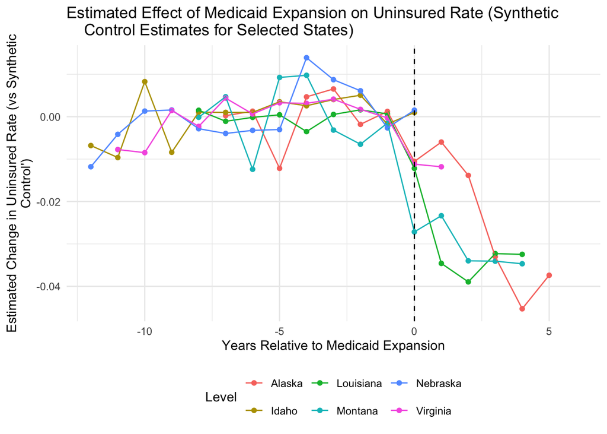

```r
# Extract the state-specific ATTs
multi_state_model_summ <- summary(multi_state_model)

# extract dataframe
att_df <- multi_state_model_summ$att

# Choose a subset of states for visibility
subset_states <- c("Alaska", "Montana", "Louisiana", "Virginia", "Idaho", "Nebraska")

# Filter the ATT dataframe to just those states
att_subset_df <- att_df %>%
  filter(Level %in% subset_states)

att_subset_df %>%
  ggplot(aes(x = Time, y = Estimate, color = Level)) +
  geom_point() +
  geom_line() +
  geom_vline(xintercept = 0, linetype = "dashed", color = "black") +
  theme_minimal() +
  theme(
    legend.position = "bottom"
  ) +
  labs(
    title = "Estimated Effect of Medicaid Expansion on Uninsured Rate (Synthetic
    Control Estimates for Selected States)",
  x = "Years Relative to Medicaid Expansion",
  y = "Estimated Change in Uninsured Rate (vs Synthetic\nControl')"
  )
```

- Estimate a multisynth model using time cohorts. For the purpose of this exercise, you can simplify the treatment time so that states that adopted Medicaid expansion within the same year (i.e. all states that adopted epxansion in 2016) count for the same cohort. Plot the treatment effects for these time cohorts.

```r
# multisynth model time cohorts

# Create cohort and treatment indicator
medicaid_expansion <- medicaid_expansion %>%
  mutate(
    cohort = year(Date_Adopted),
    treated = ifelse(!is.na(Date_Adopted) & year >= year(Date_Adopted), 1, 0)
  )

# Drop always-treated (no pre-treatment)
valid_states <- medicaid_expansion %>%
  group_by(State) %>%
  summarize(pre_treat_obs = sum(treated == 0)) %>%
  filter(pre_treat_obs > 0) %>%
  pull(State)

cohort_data <- medicaid_expansion %>%
  filter(State %in% valid_states)

# Estimate model with time cohorts
cohort_model <- multisynth(uninsured_rate ~ treated,
  State,
  year,
  cohort_data,
  n_leads = 10,
  time_cohort = TRUE
)

# Summarize results
cohort_model_summ <- summary(cohort_model)
print(cohort_model_summ)
```

```
##
## Call:
## multisynth(form = uninsured_rate ~ treated, unit = State, time = year,
##     data = cohort_data, n_leads = 10, time_cohort = TRUE)
##
## Average ATT Estimate (Std. Error): -0.016  (0.005)
##
## Global L2 Imbalance: 0.001
## Scaled Global L2 Imbalance: 0.007
## Percent improvement from uniform global weights: 99.3
##
## Individual L2 Imbalance: 0.005
## Scaled Individual L2 Imbalance: 0.015
## Percent improvement from uniform individual weights: 98.5
##
##  Time Since Treatment   Level     Estimate   Std.Error lower_bound  upper_bound
##                     0 Average -0.009699016 0.004314594 -0.01872530 -0.001948973
##                     1 Average -0.017346723 0.005819906 -0.02894032 -0.006084722
##                     2 Average -0.015234130 0.005871422 -0.02696368 -0.003760760
##                     3 Average -0.018128760 0.006177458 -0.03077496 -0.006252357
##                     4 Average -0.019448849 0.006007999 -0.03152522 -0.008130039
##                     5 Average -0.018711810 0.005729399 -0.02956803 -0.007915411
##                     6 Average -0.018354004 0.006233672 -0.03055281 -0.006306519
```

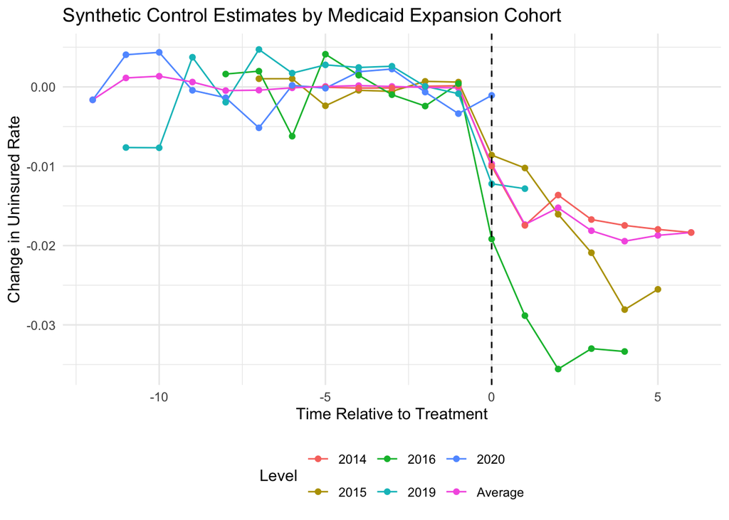

```r
# Plot
# Extract ATT data
att_df <- cohort_model_summ$att

# Plot
ggplot(att_df, aes(x = Time, y = Estimate, color = Level)) +
  geom_line() +
  geom_point() +
  geom_vline(xintercept = 0, linetype = "dashed") +
  theme_minimal() +
  labs(
    title = "Synthetic Control Estimates by Medicaid Expansion Cohort",
    x = "Time Relative to Treatment",
    y = "Change in Uninsured Rate"
  ) +
  theme(legend.position = "bottom")
```

## Discussion Questions

- One feature of Medicaid is that it is jointly administered by the federal government and the states, and states have some flexibility in how they implement Medicaid. For example, during the Trump administration, several states applied for waivers where they could add work requirements to the eligibility standards (i.e. an individual needed to work for 80 hours/month to qualify for Medicaid). Given these differences, do you see evidence for the idea that different states had different treatment effect sizes?
- **Answer**: Yes, the first graph above suggests that different states experienced different treatment effect sizes. After the treatment (post-year 0), the magnitude of the reduction in the uninsured rate varies by state. So, some states show a steep and sustained decline, while others show a more modest drop. This variation supports the idea that states implemented Medicaid expansion differently (for example, potentially due to administrative choices like waivers for work requirements or varying outreach and enrollment efforts).
- Do you see evidence for the idea that early adopters of Medicaid expansion enjoyed a larger decrease in the uninsured population?
- **Answer**: The second graph above shows some evidence that earlier adopters may have experienced a larger or more sustained decrease in the uninsured rate. Some of the lines that diverge most sharply from zero post-treatment are the 2014-2016 lines, but it is a bit challenging to gauge the effect on later years (2020, for example) because the post treatment time is not available for that cohort (we only had data through 2020). I would not feel confident making this explicit claim unless I had more cohorts/years of data - especially since the 2019 cohort shows a steeper drop than the 2015 cohort.

# General Discussion Questions

- Why are DiD and synthetic control estimates well suited to studies of aggregated units like cities, states, countries, etc?
- **Answer**: They are well suited because they are meant to estimate causal effects when RCTs are not feasible. Aggregated units like states or countries often have limited sample sizes, complex policies, and diverse characteristics. DiD allows us to use variation over time and between treated and untreated groups to control for confounders. Synthetic control methods go further by constructing a weighted combination of untreated units that more closely approximates the treated unit’s pre-treatment trajectory, offering better counterfactual estimates when units are heterogeneous.
- What role does selection into treatment play in DiD/synthetic control versus regression discontinuity? When would we want to use either method?
- **Answer**: Selection into treatment is a concern in DiD and synthetic control because units are not randomly assigned. These methods assume that, in the absence of treatment, treated and control units would have followed similar trends (parallel trends assumption in DiD; similar pre-treatment trajectories in synthetic control). Regression discontinuity (RD), on the other hand, relies on a cutoff (like an income threshold or age limit) where treatment assignment is as good as random around the threshold. If treatment is self-selected or influenced by unobserved factors, RD might be better/ more credible—but only near the cutoff. I would choose RD when there’s a clear rule-based assignment, and DiD/synthetic control when there is variation across time and units without a sharp cutoff.